# Indice Sintetico de Desigualdad Migratoria (ISDM)

Analisis con agregacion jerarquica por dimensiones - Chile Pobreza/Social imputado por interpolación lineal

Natalia Debandi

2026-02-22

# 1 Introducción

Este documento presenta la construcción de un **Índice Sintético de Desigualdad Migratoria (ISDM)** para comparar la integración socioeconómica de personas migrantes respecto a nativos en Argentina y Chile durante el período 2015-2024.

## 1.1 Metodología: Agregación jerárquica por dimensiones

El ISDM se construye mediante una **agregación jerárquica en dos niveles** que equilibra el peso de las dimensiones analíticas:

### 1.1.1 **Nivel 1: Sub-índices por dimensión**

Se calculan tres sub-índices, uno por cada dimensión:

- **Dimensión Laboral** (5 indicadores): tasa de actividad, desempleo, informalidad asalariada, informalidad total, cuentapropismo
- **Dimensión Pobreza** (2 indicadores): pobreza monetaria, pobreza extrema
- **Dimensión Social** (3 indicadores): asistencia escolar, asistencia superior, acceso a salud pública

Cada sub-índice es el **promedio de los indicadores estandarizados** (Z-scores) dentro de esa dimensión.

### 1.1.2 **Nivel 2: Agregación final**

El ISDM final es el **promedio de los tres sub-índices**, asignando **igual peso (33.3%)** a cada dimensión, independientemente del número de indicadores que contenga.

### 1.1.3 **Ventajas de este enfoque**

✓ Evita sobreponderación de dimensiones con más indicadores  
✓ Equilibra la importancia conceptual de cada área temática  
✓ Permite analizar qué dimensiones impulsan las diferencias  
✓ Facilita interpretación por dimensión analítica

# 2 Datos y clasificación

## 2.1 Carga de datos

```
## Valores imputados por interpolación lineal (Chile - Pobreza y Social):
```

```
## # A tibble: 25 × 3
##    indicador                     anio brecha_nat_mig
##    <chr>                        <dbl>          <dbl>
##  1 I10_sistema_salud_publico     2018          13.6
##  2 I10_sistema_salud_publico     2019          12.3
##  3 I10_sistema_salud_publico     2020          10.9
##  4 I10_sistema_salud_publico     2021           9.61
##  5 I10_sistema_salud_publico     2023           3.80
##  6 I6_pobreza                    2018          -3.21
##  7 I6_pobreza                    2019          -3.72
##  8 I6_pobreza                    2020          -4.22
##  9 I6_pobreza                    2021          -4.73
## 10 I6_pobreza                    2023          -6.51
## 11 I7_pobreza_extrema            2018          -2.12
## 12 I7_pobreza_extrema            2019          -2.10
## 13 I7_pobreza_extrema            2020          -2.09
## 14 I7_pobreza_extrema            2021          -2.07
## 15 I7_pobreza_extrema            2023          -2.92
## 16 I8_asistencia_escolar_6_17    2018          14.8
## 17 I8_asistencia_escolar_6_17    2019          12.3
## 18 I8_asistencia_escolar_6_17    2020           9.76
## 19 I8_asistencia_escolar_6_17    2021           7.25
## 20 I8_asistencia_escolar_6_17    2023           3.97
## 21 I9_asistencia_superior_18_29  2018          23.3
## 22 I9_asistencia_superior_18_29  2019          23.7
## 23 I9_asistencia_superior_18_29  2020          24.1
## 24 I9_asistencia_superior_18_29  2021          24.5
## 25 I9_asistencia_superior_18_29  2023          24.3
```

```
##
## ✓ Imputación completada
```

```
## ⚠ Año 2020 excluido para ambos países (distorsión pandemia)
```

```
## Dimensiones del dataset: 149 filas x 10 columnas
```

```
## Países incluidos: Argentina, Chile
```

```
## Período de análisis: 2015 - 2024
```

```
## Número de indicadores: 10
```

## 2.2 Clasificación de indicadores por dimensión

Tabla 1: Clasificación de indicadores por dimensión y dirección interpretativa

| Indicador | Dimensión | Tipo | Interpretación |
| --- | --- | --- | --- |
| I1_tasa_actividad | Laboral | positivo | Mayor actividad = Mejor integración |
| I2_tasa_desempleo | Laboral | negativo | Mayor desempleo = PEOR integración |
| I3_informalidad_asalariada | Laboral | negativo | Mayor informalidad = PEOR integración |
| I4_informalidad_total | Laboral | negativo | Mayor informalidad = PEOR integración |
| I5_cuentapropismo | Laboral | negativo | Mayor cuentapropismo = PEOR integración |
| I6_pobreza | Pobreza | negativo | Mayor pobreza = PEOR integración |
| I7_pobreza_extrema | Pobreza | negativo | Mayor pobreza extrema = PEOR integración |
| I8_asistencia_escolar_6_17 | Social | positivo | Mayor asistencia = MEJOR integración |
| I9_asistencia_superior_18_29 | Social | positivo | Mayor asistencia = MEJOR integración |
| I10_sistema_salud_publico | Social | positivo | Mayor acceso salud pública = MEJOR integración |

### 2.2.1 Distribución de indicadores

```
##
## DISTRIBUCIÓN DE INDICADORES POR DIMENSIÓN
```

Tabla 2: Ponderación implícita según tipo de agregación

| Dimensión | N° Indicadores | Peso Agregación Directa (%) | Peso Agregación Jerárquica (%) |
| --- | --- | --- | --- |
| Laboral | 5 | 50 | 33.3 |
| Pobreza | 2 | 20 | 33.3 |
| Social | 3 | 30 | 33.3 |

```
##
## ✓ Con agregación jerárquica, cada dimensión pesa exactamente 33.3%
```

```
##   independientemente del número de indicadores que contenga.
```

# 3 Procesamiento de brechas

## 3.1 Normalización direccional

La **normalización direccional** invierte el signo de las brechas para indicadores negativos, de modo que todos se interpreten en la misma dirección:

- **Brecha > 0** → Nativos mejor integrados
- **Brecha < 0** → Migrantes mejor integrados

$$\text{Brecha normalizada} = \begin{cases}
\text{Brecha original} & \text{si el indicador es POSITIVO} \\
-(\text{Brecha original}) & \text{si el indicador es NEGATIVO}
\end{cases}$$

```
## ✓ Normalización direccional completada
```

```
## Observaciones procesadas: 149
```

## 3.2 Estandarización estadística (Z-scores)

La **estandarización** transforma cada brecha a desviaciones estándar, equilibrando el peso de indicadores con diferentes variabilidades:

$$Z_i = \frac{x_i - \bar{x}_i}{\sigma_i}$$

```
## ✓ Estandarización completada
```

```
## Verificación de estandarización:
```

```
##   • Media de Z-scores: -0.000000 (esperado: ~0)
```

```
##   • SD de Z-scores: 1.000000 (esperado: ~1)
```

# 4 Visualización de brechas por dimensión (sin estandarizar)

[figure not shown]

```
## ✓ Gráfico guardado: output_graficos/fig1a_brechas_laboral_original.png
```

[figure not shown]

```
## ✓ Gráfico guardado: output_graficos/fig1b_brechas_pobreza_original.png
```

[figure not shown]

```
## ✓ Gráfico guardado: output_graficos/fig1c_brechas_social_original.png
```

### 4.0.1 Tabla de brechas promedio

Tabla 1: Brechas promedio en Dimensión Laboral (2015-2024)

| Indicador | Brecha promedio (Nativos - Migrantes) Argentina (pp) | Brecha promedio (Nativos - Migrantes) Chile (pp) |
| --- | --- | --- |
| Cuentapropismo | 5.58 | -3.84 |
| Informalidad Asalariada | 12.83 | 0.47 |
| Informalidad Total | 12.00 | -6.47 |
| Tasa Actividad | -9.17 | -18.89 |
| Tasa Desempleo | -0.93 | -0.24 |

Nota: Valores positivos indican ventaja de nativos; valores negativos indican ventaja de migrantes.

Tabla 2: Brechas promedio en Dimensión Pobreza (2015-2024)

| Indicador | Brecha promedio (Nativos - Migrantes) Argentina (pp) | Brecha promedio (Nativos - Migrantes) Chile (pp) |
| --- | --- | --- |
| Pobreza | -1.32 | 3.96 |
| Pobreza Extrema | 0.78 | 2.23 |

Nota: Valores positivos indican ventaja de nativos; valores negativos indican ventaja de migrantes.

Tabla 3: Brechas promedio en Dimensión Social (2015-2024)

| Indicador | Brecha promedio (Nativos - Migrantes) Argentina (pp) | Brecha promedio (Nativos - Migrantes) Chile (pp) |
| --- | --- | --- |
| Asistencia Escolar 6 17 | 2.07 | 8.51 |
| Asistencia Superior 18 29 | 1.99 | 23.49 |
| I10 Sistema Salud Publico | -7.56 | 9.79 |

Nota: Valores positivos indican ventaja de nativos; valores negativos indican ventaja de migrantes.

Tabla 4: Comparación de brechas entre países (2015-2024)

| Dimensión | Indicador | Brecha promedio Argentina (pp) | Brecha promedio Chile (pp) | Comparación Diferencia (Chile - Arg | Comparación \|Mayor brecha |
| --- | --- | --- | --- | --- | --- |
| **Laboral** |  |  |  |  |  |
| Laboral | Cuentapropismo | 5.58 | -3.84 | -9.42 | Argentina |
| Laboral | Informalidad Asalariada | 12.83 | 0.47 | -12.36 | Argentina |
| Laboral | Informalidad Total | 12.00 | -6.47 | -18.47 | Argentina |
| Laboral | Tasa Actividad | -9.17 | -18.89 | -9.72 | Chile |
| Laboral | Tasa Desempleo | -0.93 | -0.24 | 0.69 | Argentina |
| **Pobreza** |  |  |  |  |  |
| Pobreza | Pobreza | -1.32 | 3.96 | 5.29 | Chile |
| Pobreza | Pobreza Extrema | 0.78 | 2.23 | 1.46 | Chile |
| **Social** |  |  |  |  |  |
| Social | Asistencia Escolar 6 17 | 2.07 | 8.51 | 6.44 | Chile |
| Social | Asistencia Superior 18 29 | 1.99 | 23.49 | 21.50 | Chile |
| Social | I10 Sistema Salud Publico | -7.56 | 9.79 | 17.35 | Chile |

# 5 Visualización de brechas por dimensión estandarizadas

A continuación se presentan las distribuciones de las brechas estandarizadas para cada dimensión analítica.

## 5.1 Dimensión Laboral

[figure not shown]

```
## ✓ Gráfico guardado: output_graficos/fig1a_brechas_laboral.png
```

## 5.2 Dimensión Pobreza

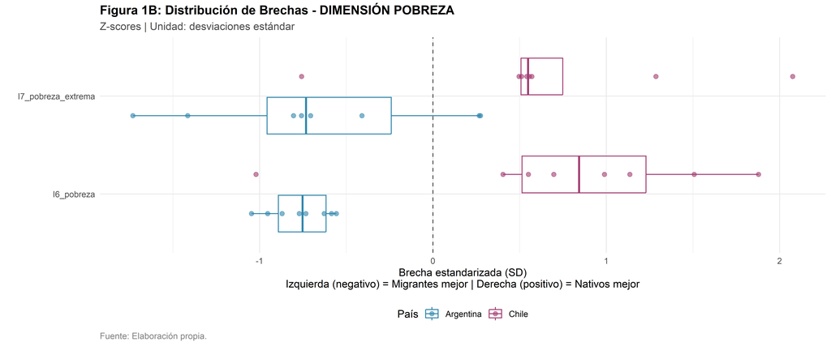

```
## ✓ Gráfico guardado: output_graficos/fig1b_brechas_pobreza.png
```

## 5.3 Dimensión Social

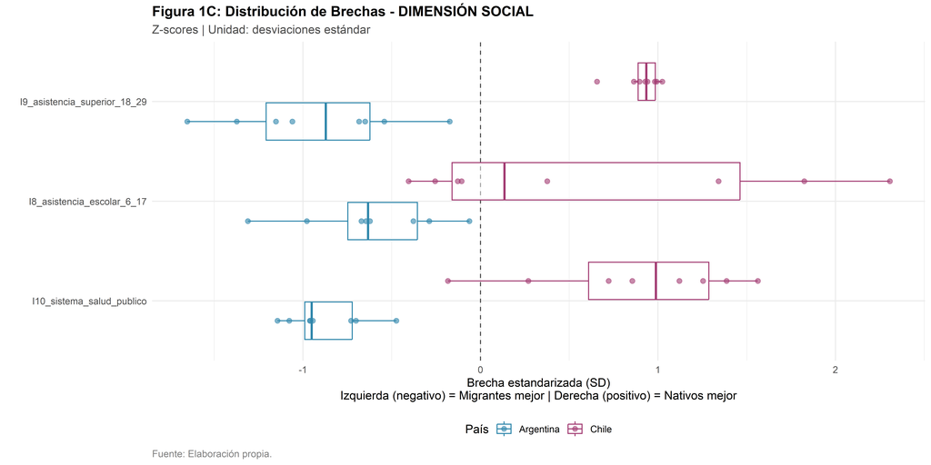

```
## ✓ Gráfico guardado: output_graficos/fig1c_brechas_social.png
```

# 6 Construcción del ISDM jerárquico

## 6.1 Paso 1: Sub-índices por dimensión

```
## ✓ Sub-índices por dimensión calculados
```

Tabla 3: Ejemplo de sub-índices por dimensión (año 2024)

| País | Dimensión | Sub-índice Absoluto (SD) | Sub-índice Direccional (pp) |
| --- | --- | --- | --- |
| Argentina | Laboral | 0.709 | 3.664 |
| Argentina | Pobreza | 1.300 | -1.038 |
| Argentina | Social | 1.120 | -4.229 |
| Chile | Laboral | 0.734 | -3.489 |
| Chile | Pobreza | 1.977 | 5.790 |
| Chile | Social | 0.509 | 8.778 |

## 6.2 Paso 2: Agregación final (ISDM)

```
## ✓ ISDM final calculado
```

Tabla 4: Serie temporal del ISDM (agregación jerárquica)

| País | Año | ISDM Absoluto (SD) | ISDM Direccional (pp) |
| --- | --- | --- | --- |
| Argentina | 2016 | 0.749 | 2.042 |
| Argentina | 2017 | 0.672 | 1.615 |
| Argentina | 2018 | 0.616 | 1.663 |
| Argentina | 2019 | 0.795 | 0.753 |
| Argentina | 2021 | 0.586 | 0.622 |
| Argentina | 2022 | 0.806 | 0.489 |
| Argentina | 2023 | 0.790 | 0.342 |
| Argentina | 2024 | 1.043 | -0.534 |
| Chile | 2015 | 1.035 | 2.152 |
| Chile | 2017 | 1.126 | 3.986 |
| Chile | 2018 | 1.199 | 4.558 |
| Chile | 2019 | 0.962 | 4.087 |
| Chile | 2021 | 0.780 | 3.350 |
| Chile | 2022 | 0.705 | 4.061 |
| Chile | 2023 | 0.835 | 3.333 |
| Chile | 2024 | 1.073 | 3.693 |

# 7 Resultados principales

## 7.1 Promedios 2015-2024

```
##
## RESULTADOS PRINCIPALES (PROMEDIO 2015-2024)
```

Tabla 5: ISDM promedio por país (2015-2024)

[output not shown]

```
##
##
## INTERPRETACIÓN:
```

```
## 1. MAGNITUD DE LA DESIGUALDAD:
```

```
##    • Argentina: 0.757 SD
```

```
##    • Chile: 0.965 SD
```

```
##    → Chile presenta 27.4% MAYOR desigualdad que Argentina
```

```
## 2. DIRECCIÓN DE LA DESIGUALDAD:
```

```
##    • Argentina: +0.87 pp → Nativos MEJOR integrados
```

```
##    • Chile:     +3.65 pp → Nativos MEJOR integrados
```

## 7.2 Tests estadísticos y robustez

```
##
## TEST DE DIFERENCIA ENTRE PAÍSES
```

```
## Prueba de normalidad Shapiro-Wilk para ISDM Absoluto:
```

```
##   • Argentina: W = 0.9080, p-valor = 0.3404 → Distribución NORMAL (p ≥ 0.05)
```

```
##   • Chile:     W = 0.9551, p-valor = 0.7626 → Distribución NORMAL (p ≥ 0.05)
```

```
##   ✓ Ambos grupos cumplen normalidad: el test t de Student es apropiado.
```

```
## Test t de Student para ISDM Absoluto:
```

```
##   • Estadístico t: -2.5925
```

```
##   • p-valor: 0.0218
```

```
##   • IC 95%: [-0.3799, -0.0352]
```

```
##   ✓ Diferencias ESTADÍSTICAMENTE SIGNIFICATIVAS (p < 0.05)
```

```
## Diferencia de medias observada:
```

```
##   • Media Argentina: 0.7570 SD  (n = 8)
```

```
##   • Media Chile:     0.9645 SD  (n = 8)
```

```
##   • Diferencia (Arg - Chl): -0.2075 SD
```

```
## Tamaño del efecto - Cohen's d:
```

```
##   • SD pooled:  0.1601
```

```
##   • Cohen's d:  -1.2963 → efecto GRANDE
```

```
##   Referencia: |d| < 0.2 pequeño | 0.2–0.5 pequeño-moderado | 0.5–0.8 moderado | > 0.8 grande
```

```
## Permutation test (n = 10.000 permutaciones):
```

```
##   • Diferencia observada:    -0.2075 SD
```

```
##   • p-valor permutación:     0.0230
```

```
##   ✓ Diferencias SIGNIFICATIVAS según permutation test (p < 0.05)
```

```
## RESUMEN DE PRUEBAS:
```

[output not shown]

```
##   Permutation test:            p = 0.0230  ✓ Significativo
```

```
##   Cohen's d:                   d = -1.2963  efecto GRANDE
```

# 8 Análisis por dimensiones

## 8.1 Sub-índices promedio

```
##
## DESIGUALDAD POR DIMENSIÓN ANALÍTICA
```

Tabla 6: Sub-índices promedio por dimensión (2015-2024)

| País | Dimensión | Sub-índice Absoluto (SD) | Sub-índice Direccional (pp) |
| --- | --- | --- | --- |
| Argentina | Laboral | 0.688 | 4.060 |
| Argentina | Pobreza | 0.782 | -0.272 |
| Argentina | Social | 0.801 | -1.166 |
| Chile | Laboral | 1.067 | -6.073 |
| Chile | Pobreza | 0.936 | 3.099 |
| Chile | Social | 0.891 | 13.932 |

```
##
##
## RANKING DE DIMENSIONES POR MAGNITUD DE DESIGUALDAD:
```

```
## Argentina:
##   1. Social (0.801 SD)
##   2. Pobreza (0.782 SD)
##   3. Laboral (0.688 SD)
##
## Chile:
##   1. Laboral (1.067 SD)
##   2. Pobreza (0.936 SD)
##   3. Social (0.891 SD)
```

## 8.2 Visualización: Barras por dimensión

[figure not shown]

```
## ✓ Gráfico guardado: output_graficos/fig2_dimensiones_barras.png
```

## 8.3 Evolución temporal por dimensión

[figure not shown]

```
## ✓ Gráfico guardado: output_graficos/fig3_evolucion_dimensiones.png
```

# 9 Evolución del ISDM total

## 9.1 Serie temporal

[figure not shown]

```
## ✓ Gráfico guardado: output_graficos/fig4_evolucion_isdm.png
```

## 9.2 Comparación de promedios

[figure not shown]

```
## ✓ Gráfico guardado: output_graficos/fig5_comparacion_paises.png
```

Visualizacion de diferencias segun dimension

- opcion barras

[figure not shown]

```
## ✓ Gráfico guardado: output_graficos/fig_subindices_direccionales.png
```

# 10 Conclusiones

## 10.1 Hallazgos principales

### 10.1.1 1. Magnitud de la desigualdad migratoria

- **Chile** presenta 27.4% mayor desigualdad que **Argentina**
- ISDM promedio: Chile = 0.965 SD vs. Argentina = 0.757 SD

### 10.1.2 2. Desigualdad por dimensión

**Chile:**

1. Laboral (1.067 SD)
2. Pobreza (0.936 SD)
3. Social (0.891 SD)

**Argentina:**

1. Social (0.801 SD)
2. Pobreza (0.782 SD)
3. Laboral (0.688 SD)

### 10.1.3 3. Significancia estadística

- Las diferencias entre países son **estadísticamente significativas** (p = 0.0218)

### 10.1.4 4. Ventajas de la agregación jerárquica

- ✓ Equilibra el peso de las tres dimensiones (33.3% cada una)
- ✓ Evita que la dimensión laboral domine el índice (peso reducido de 50% a 33%)
- ✓ Permite identificar qué áreas impulsan las diferencias entre países
- ✓ Facilita interpretación conceptual por dimensión analítica

# 11 Referencias metodológicas

- **Agregación jerárquica**: Construcción de índices compuestos mediante sub-índices dimensionales (OECD, 2008)
- **Normalización direccional**: Técnica de recodificación para alinear interpretación de indicadores heterogéneos
- **Estandarización Z-score**: $(x - \mu) / \sigma$, método estándar en análisis multivariado (Johnson & Wichern, 2007)
- **Índices sintéticos**: Agregación de múltiples indicadores en medida única (PNUD)

# 12 Información de sesión

```
##
## ## Software utilizado
```

```
## **R version:** R version 4.5.2 (2025-10-31 ucrt)
```

```
## **Paquetes principales:**
```

```
##   • tidyverse: 2.0.0
```

```
##   • knitr: 1.51
```

```
##   • kableExtra: 1.4.0
```

```
## **Fecha de generación:** 2026-02-22 19:50:10
```

**Documento generado automáticamente mediante R Markdown**  
**Autora:** Natalia Debandi

*Nota: Todos los gráficos han sido guardados en formato PNG de alta resolución (300 dpi) en la carpeta `output_graficos/` para su uso en publicaciones.*